# Taking a look at the history of VCT

This project focuses on analyzing Valorant Champions Tour Esports Tournament Data. Spanning from Maps Banned, Round Results, Player Stats, and more. Taking a look at the history and answering different questions spanning across different categories.

Throughout this project, there will be lots of text to read through which will also provide an understanding of the core gameplay concepts that should allow a deeper insight into the descriptions of the data. We look at different questions.

### What questions are we asking?

- Which years had the most overtime matches played?
- Which team has the most wins in Overtime within the last 2 years?
- What map has stayed consistantly banned throught the history of the league within the draft pick phase?
- Which player has been the best throughout the leagues history and within the seasons?

## Introduction & Overview

Link to Dataset [Here](https://www.kaggle.com/datasets/ryanluong1/valorant-champion-tour-2021-2023-data/data)

```python
%pip install numpy pandas matplotlib seaborn
```

## Importing the libraries and Setup

```python
# First Load up all the librarys needed.

import pandas as pd
import numpy as np
import matplotlib.pyplot as plt
import seaborn as sns
from pandas import DataFrame


class VCTAgentData:
    def __init__(self, year):
      self.agents_pr = pd.read_csv(f"./data/vct_{year}/agents/agents_pick_rates.csv")
      self.map_stats = pd.read_csv(f"./data/vct_{year}/agents/maps_stats.csv")

class VCTMatchData:
    def __init__(self, year):
      self.WinLossRounds = pd.read_csv(f"./data/vct_{year}/matches/win_loss_methods_round_number.csv")
      self.MapScores = pd.read_csv(f"./data/vct_{year}/matches/maps_scores.csv")
      self.DraftPhase = pd.read_csv(f"./data/vct_{year}/matches/draft_phase.csv")

class VCTPlayerData:
    def __init__(self, year):
      self.PlayerStats = pd.read_csv(f"./data/vct_{year}/players_stats/players_stats.csv")


class VCTData:
  def __init__(self, year):
    self.Agents = VCTAgentData(year)
    self.Matches = VCTMatchData(year)
    self.Player = VCTPlayerData(year)

vct2023 = VCTData("2023")
vct2024 = VCTData("2024")
```

## Pre-Processing

First, I wanted to check through the data. Since We are working with different cases on a large scale there is a lot to check. Within our data set, we are going to be viewing from 2022 onwards. We first want to check for nulls within our data to avoid any errors during analysis and improve the quality of the data.

Due to the amount of data that is presented, there will be many pre-processing steps that will happen when the data is used and not at first. Finding many different helper methods, will showcase the pre-processing data.

```python
# Check and Print the null data
# Here is the amount of data that we will be going through.
print("2023 Data: \n")
print(vct2023.Agents.agents_pr.shape)
print(vct2023.Agents.map_stats.shape)
print(vct2023.Matches.DraftPhase.shape)
print(vct2023.Matches.MapScores.shape)
print(vct2023.Matches.WinLossRounds.shape)
print(vct2023.Player.PlayerStats.shape)


print("2024 Data: \n")
print(vct2024.Agents.agents_pr.shape)
print(vct2024.Agents.map_stats.shape)
print(vct2024.Matches.DraftPhase.shape)
print(vct2024.Matches.MapScores.shape)
print(vct2024.Matches.WinLossRounds.shape)
print(vct2024.Player.PlayerStats.shape)
```

[output not shown]

```python
print("2023 WinLoss Data: \n", vct2023.Matches.WinLossRounds.isnull().sum())
print("2024 WinLoss Data: \n", vct2024.Matches.WinLossRounds.isnull().sum())
```

[output not shown]

As we can see the data that comes along with the dataset itself is very clean and is full with the proper information. During different quesitions we will be diving into different datasets and filtering and changing it in different ways. Although there is something we need to take care of.

Within the data for the year of 2022, data is substancally different due to the VCT league having a different structure. For the sake of the data here, we will be removing Challengers Tournaments from the data. These are apart of a seperate league, which is not apart of what we want to look at. We will be taking a look at the higher level tournaments, while comparing to the others.

```python
# We need to filter out all rows that contain data from a challengers tournament. This is easy to do.

def filter_challengers(df:DataFrame):
    df = df[~df['Tournament'].str.contains("Challengers")]
    return df

# We also want to give these matches an identifier so we can sort through the same game fast.
def createMatchIdentifier(df:DataFrame):
    df['Identity'] = df['Tournament'] + '_' + df['Stage'] + '_' + df['Match Type'] + "_" + df['Map']
    return df

vct2022.Matches.WinLossRounds = filter_challengers(vct2022.Matches.WinLossRounds)
createMatchIdentifier(vct2023.Matches.WinLossRounds).head(1)
```

|  | Tournament | Stage | Match Type | Match Name | Map | Round Number | Team | Method | Outcome | Identity |
| --- | --- | --- | --- | --- | --- | --- | --- | --- | --- | --- |
| 0 | Valorant Champions 2023 | Group Stage | Opening (D) | Team Liquid vs Natus Vincere | Fracture | 1 | Team Liquid | Elimination | Win | Valorant Champions 2023_Group Stage_Opening (D... |

# Data Understanding/Visualization

## Which team plays best under pressure?

Within VALORANT, the core game mode is set to a Round-Based Plant defensive mode. Well, what does that mean?

Teams play 12 rounds on either Attack or Defense, then swap to the other side to play another 12 rounds. The first to achieve 13-round wins. If a game reaches a tie game of 12-12, the game goes into overtime where the first team to get a 2-round lead on their opponent wins the game.

Throughout the years there have been many different overtimes that occur throughout preliminary and even final matches. I wanted to take a look at the different games that.

### So, how many blood-pumping overtimes did we have?

Overtime is not as common as you think. First, let's look at how many tournaments and how many matches did we have.

[figure not shown]

```python
def numOfTournaments(df:DataFrame):
    return len(df['Tournament'].unique())
tour = pd.Series([ numOfTournaments(vct2022.Matches.WinLossRounds), numOfTournaments(vct2023.Matches.WinLossRounds), numOfTournaments(vct2024.Matches.WinLossRounds)])
tpy = pd.DataFrame({'Years': pd.Series([2022,2023,2024]), 'Tournaments':  tour});
tpy.plot(x='Years', y='Tournaments', kind='bar')
```

##### 20 in 2022, 10 in 2023, 15 in 2024

As we can see it's a fluctuating number. Over the course of the history of the league, there have been changes to the format as it has only been around for just a few years. The league continues to improve and evolve with time. This is why we will be mainly focusing on 2023 and 2024. These 2 years, officialized the league's format which makes the data overall more consistent to look at. While 2022 was the first year of the league, 2023 transitioned into a Partner-based system where Teams were selected by Riot Games and invited to play within the league.

## Which Years had the most Overtime Matches Played?

As mentioned before when a match gets to round 25 it is considered to be an overtime round. In Valorant if each team takes a round, the overtime continues until there is a victor. We will be taking a look at how many matches went into overtime and how many overtime rounds we have had.

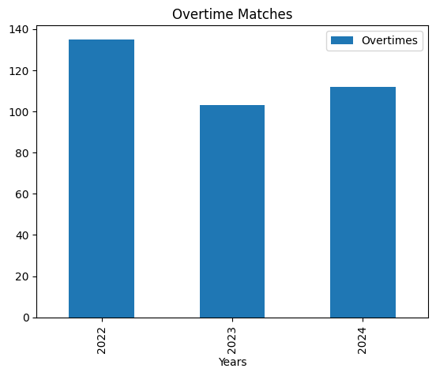

```python
# Firstly lets look at the number of tournaments for the first year, get a pattern down to replicate for others.
# Within the data we need to take a look at a pattern.

# First lets get all of the over time rounds.

def getFirstOverTime(df:DataFrame):
    cp = df.copy()
    cp.dropna()
    # First lets get all of the over time rounds.
    cp = cp.loc[cp['Round Number'] == 25]
    # Second we just want to see all the wins, doing this also filters out the double up on unique rows per round.
    cp = cp[cp['Outcome'] == "Win"]
    return cp

firstOt2022 = getFirstOverTime(vct2022.Matches.WinLossRounds)

# now that the data has been sorted. We now have round 25 which indicates the first round of overtime played which is the required round that we can see a unique number of overtimes.

# Now we can showcase how many first overtimes there were throughout the year.
tpy = pd.DataFrame({'Years': pd.Series([2022,2023,2024]), 'Overtimes':  pd.Series([len(firstOt2022),len(getFirstOverTime(vct2023.Matches.WinLossRounds)),len(getFirstOverTime(vct2024.Matches.WinLossRounds))])});
tpy.plot(x='Years', y='Overtimes', kind='bar', title="Overtime Matches")
```

## So what are we looking at here

What we should take a look at is the ratio of overtime per match to get a more accurate representation of where overtime felt the most overwhelming.

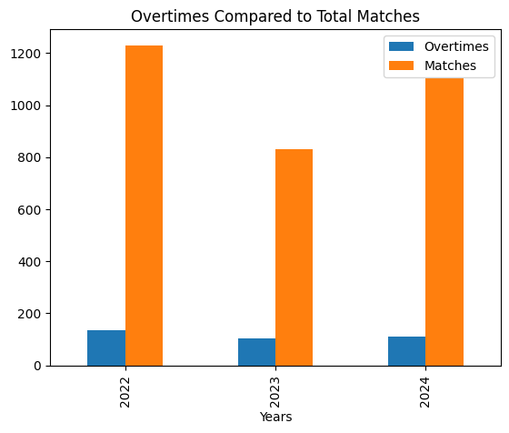

```python
# Lets get the number of matches we had.

def getNumberOfUniqueMatches(df: DataFrame):
    cp = df.copy()
    cp.dropna()
    # First lets get of the first rounds, this allows us to see all of the matches.
    cp = cp.loc[cp['Round Number'] == 1]
    # Second we just want to see all the wins, doing this also filters out the double up on unique rows per round.
    cp = cp[cp['Outcome'] == "Win"]
    return cp

tpy['Matches'] = [len(getNumberOfUniqueMatches(vct2022.Matches.WinLossRounds)), len(getNumberOfUniqueMatches(vct2023.Matches.WinLossRounds)), len(getNumberOfUniqueMatches(vct2024.Matches.WinLossRounds))]

tpy.plot(x="Years", y=["Overtimes", "Matches"], kind="bar", title="Overtimes Compared to Total Matches")
```

```python
def determinePercentageOf(a, b):
    return (a/b);

tpy.head()
tpy["PoOT"] = determinePercentageOf(tpy['Overtimes'], tpy['Matches'])
tpy['PoOT'] = tpy["PoOT"].map('{:.2%}'.format)

print(tpy)
```

```
   Years  Overtimes  Matches    PoOT
0   2022        135     1230  10.98%
1   2023        103      830  12.41%
2   2024        112     1104  10.14%
```

### We can see that overtime is not common.

In 2022 we had 1230 matches where only 135 resulted in overtime leading to almost an 11% chance where a match round. In the following years, 2023 had 830 matches with only 103 of them resulting in overtime being played. Last but not least, would be 2024, with over 1104 matches played and 112 overtimes played.

## So which team showed up the most during Overtime?

Now that we have looked at the number of unique overtimes we have had, who came out on top? To do this, we need to take a look at different teams, first let's look at how many overtimes, each team participated in.

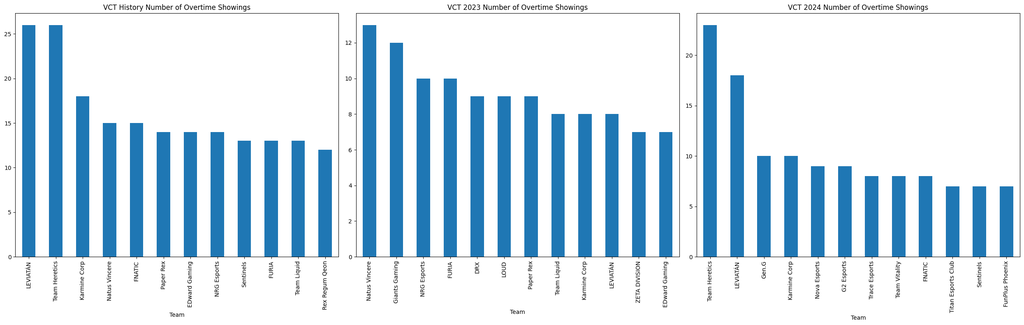

```python
# First we want to get all of the overtimes rounds that are wins. Similar to what we did before, we now just want every value of overtime
def getAllOverTimeRounds(df:DataFrame):
    cp = df.copy()
    cp.dropna()
    # First lets get all of the over time rounds.
    cp = cp.loc[cp['Round Number'] >= 24]
    # Second we just want to see all the wins, doing this also filters out the double up on unique rows per round.
    cp = cp[cp['Outcome'] == "Win"]
    # This allows the removal of the second round that is played. Can be used to remove the first round instead of wanted.
    cp = cp.loc[cp['Round Number'] % 2 == 1]
    cp = cp['Team'].value_counts().head(12)
    return cp
cOT = pd.concat([vct2023.Matches.WinLossRounds,vct2024.Matches.WinLossRounds], ignore_index=True)
cOT = getAllOverTimeRounds(cOT)
OT_2023_Rounds = getAllOverTimeRounds(vct2023.Matches.WinLossRounds)
OT_2024_Rounds = getAllOverTimeRounds(vct2024.Matches.WinLossRounds)

fig, axes = plt.subplots(1,3, figsize=(25,8))
allDataSetsforOT = [(cOT, "VCT History Number of Overtime Showings"), (OT_2023_Rounds, "VCT 2023 Number of Overtime Showings"), (OT_2024_Rounds, "VCT 2024 Number of Overtime Showings")]
for i, (dataplot, title) in enumerate(allDataSetsforOT):
    dataplot.plot(x=dataplot.index, y=dataplot.values, kind="bar", title=title, ax=axes[i])

plt.tight_layout()
```

As we can see "LEVIATAN" & "Team Heritics" are historicly the teams who had the most Series Map Matches to end up in an Overtime.

We have looked at the number of unique overtimes we have had but, who came out on top? To do this, we need to take a look at different teams, first let's look at how many overtimes, each team participated in.

## Which team has the most overtime wins?

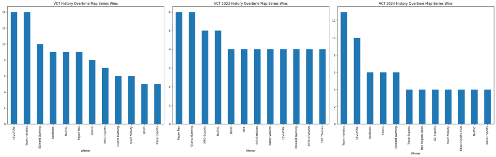

```python
# To get the teams that won the most overtimes we need to take a look at the overview of all the matches.
# First we need to filter for just the matches that contains overtime. Looking at the data this is pretty easy as all we need to do is look for null points
vct2024.Matches.MapScores.isnull().sum()

def determineOvertimeWins(df : DataFrame):
    df = df.dropna(subset=['Team A Overtime Score', 'Team B Overtime Score'])
    df['Winner']= np.where(
        df['Team A Overtime Score'] > df['Team B Overtime Score'],
        df['Team A'],
        df['Team B']
    )
    df = df['Winner'].value_counts().head(12)
    return df
cMS = pd.concat([vct2023.Matches.MapScores,vct2024.Matches.MapScores], ignore_index=True)
cMS = determineOvertimeWins(cMS)
ms23 = determineOvertimeWins(vct2023.Matches.MapScores);
ms24 = determineOvertimeWins(vct2024.Matches.MapScores);

fig, axes = plt.subplots(1,3, figsize=(25,8))
allDataSetsforDF = [(cMS, "VCT History Overtime Map Series Wins"), (ms23, "VCT 2023 History Overtime Map Series Wins"), (ms24, "VCT 2024 History Overtime Map Series Wins")]
for i, (dataplot, title) in enumerate(allDataSetsforDF):
    ax = axes[i]
    dataplot.plot(x=dataplot.index, y=dataplot.values, kind="bar", title=title, ax=ax)

plt.tight_layout()
```

## What map has stayed consistently banned throughout the history of the league?

Maps within VALORANT are the areas of play within the game. Each map has a unique layout and a unique mechanic that makes it different from other maps. For example, Map Haven was introduced at the launch of the game with 3 different spike sites instead of the normal 2 we have come to know in traditional tactical fps shooters. Icebox was introduced as the first map to contain horizontal zip lines, and a map like Bind introduced teleporters on the map which allowed you to rotate across the map quickly. No 2 maps are alike, each offering their unique gameplay which teams and players need to adapt and choose a correct composition to succeed.

Throughout the VCT league, there have been different Map Pools. A Map Pool is essentially a group of Maps that players can select to play from within their competitive matches. There is no set pattern onto which maps get removed. As the map pool has changed there have been different maps that have been highly favored or looked down upon.

Due to this, I want to take a look at which maps have been consistently banned. Banning a map removes the option from the opponent to select the map during a Pick/Ban Stage. In a best of 3, 4 maps are banned with 3 maps being selected. In a best of 5, only 2 maps are banned. Teams often have better maps that they perform on which they tend to favor or their opponent can choose to ban.

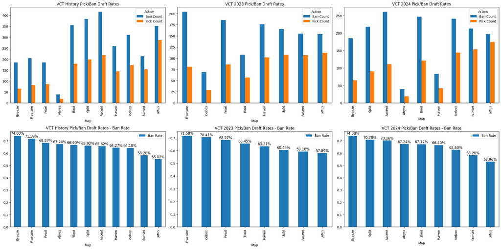

```python
def DetermineMapPickRate(df: DataFrame):
    test = df.copy()
    test = test.groupby('Map')['Action'].value_counts().unstack(fill_value=0)
    test["Overall"] = test["ban"] + test["pick"]
    test["Ban Rate"] = determinePercentageOf(test['ban'], test['Overall'])
    test['Ban Rate Label'] = test["Ban Rate"].map('{:.2%}'.format)
    test = test.rename(columns={'ban': 'Ban Count', 'pick': 'Pick Count'})
    test = test.reset_index() # This is interesting but this is used to make the index into a column. Stuck here for awhile
    test = test.sort_values(by="Ban Rate", ascending=False)
    return test
# we want to get the ban rate. we want to see the number of bans have gotten overall.
df_23 = vct2023.Matches.DraftPhase
df_24 = vct2024.Matches.DraftPhase

combination = pd.concat([df_23,df_24], ignore_index=True)
allTime = DetermineMapPickRate(combination)
df23 = DetermineMapPickRate(df_23)
df24 = DetermineMapPickRate(df_24)

fig, axes = plt.subplots(2,3, figsize=(22,11))
allDataSetsforDF = [(allTime, "VCT History Pick/Ban Draft Rates"), (df23, "VCT 2023 Pick/Ban Draft Rates"), (df24, "VCT 2024 Pick/Ban Draft Rates")]

for i, (dataplot, title) in enumerate(allDataSetsforDF):
    ax = axes[0,i]
    dataplot.plot(x='Map', y=["Ban Count", "Pick Count"], kind="bar", title=title, ax=ax)

for i, (dpa, title) in enumerate(allDataSetsforDF):
    ax = axes[1,i] # Second Row
    dpa.plot(x='Map', y='Ban Rate', kind="bar", title=f"{title} - Ban Rate", ax=ax)

    for j, bar in enumerate(ax.patches):
        height = bar.get_height()
        ax.text(bar.get_x() + bar.get_width() / 2, height + 0.01,
        f"{dpa['Ban Rate Label'].iloc[j]}", ha='center', fontsize=11, color='black')


plt.tight_layout()
# Grouping the Values allows us to see the Map to Action ratio. Unstacking it allows ban and pick to be sorted into different columns. Value_Counts does what it says lol.
# we also want to get the pick rate.
# we need to get the overall number that the map has been mentioned. Some maps dont get selected at all.
```

## Which Player is the best within the last 2 years?

Players come in and out throughout the VCT league. Teams are always looking for upcoming talent to improve their roaster. With this, there has been a plethora of different players throughout the history of the league. I wanted to see which player has ranked the best throughout the years. To do this we want to get a collective score of how a player performs. Within VALORANT there are many different factors that could influence this, including Kills, Deaths, Assists, First Kills, Ability usage, and more. Our dataset here is limited to only a few factors so what we will do is create an imaginary score that uses different metrics. This is often used in different eSports Statistics websites due to the amount of different factors that could influence a match. Included within the dataset is one of these scores by the site "VLR". We will not be using this score to try something different and have a more generic rating across the board, the value "Average Combat Score" does take in more of these factors and outputs a generic score. We will be using a mix of these for a calculation, and applying different weights for how much they should apply for.

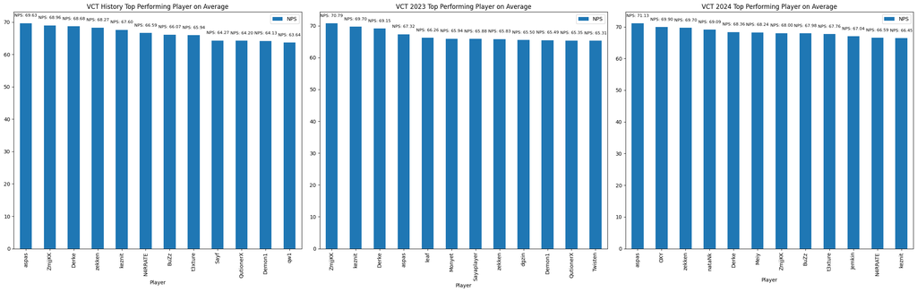

```python
def determineScore(df : DataFrame):
    # First we want to get the KDA of the player
    cs = 0
    cs += ((df['Kills'] + df['Assists']) / df['Deaths']) * .4 # Weight of KDA 40%
    # FDs and FKs are like bonus points in this senario.
    if(df['First Deaths'] != 0):
        cs += (df['First Kills'] / df['First Deaths']) * .2 # Weight of FKs/FD are 20%
    else:
        cs += df['First Kills']
    cs += convertPercent(df['Headshot %']) * .15 # Weight of Headshot Percentage is 15%
    cs += df['Average Combat Score'] * .25 # Weight of CombatScore is 25%, this is a value which includes many different aspects, and is used as a slight baseline.
    cs += convertPercent(df['Clutch Success %']) * .20 # Weight of Headshot Percentage is a Bonus over 100% at a 20% bonus
    return cs

def cleanPlayerStats(df : DataFrame):
    # Instead of just removing each rows, we are just going to get the columns that we want.
    df = df[['Player', 'Agents', 'Average Combat Score', 'Headshot %', 'Clutch Success %', 'Kills', 'Deaths', 'Assists', 'First Kills', 'First Deaths' ]]
    # We also want to remove any rows that contains more than 1 agent. To not have multiple values, this is pretty easy as we just need to look for a comma within the agent value.
    df = df[~df['Agents'].str.contains(", ")]
    df["PlayCount"] = df.groupby('Player')['Player'].transform('size')
    df['Headshot %'] = df['Headshot %'].fillna(str("0%"))
    df['Clutch Success %'] = df['Clutch Success %'].fillna(str("0%"))
    df['Average Combat Score'] = df['Average Combat Score'].fillna(0)
    return df

def convertPercent(pString : str):
    if(type(pString) == float): #???? I hate python
        return 0
    return int(pString.replace('%', ''))

def getPlayerScores(df : DataFrame, minimumMatches = 20):
    df = cleanPlayerStats(df)
    df['PScore'] = df.apply(determineScore, axis=1)

    # we want to normalize the score by the number of entries a player has, we want to make sure that a player has at least played 20 matches. to get rid of any outliers.
    df = df[df['PlayCount'] >= minimumMatches]
    df = df.sort_values(by='PlayCount', ascending=True)
    df.head()
    df["NPS"] = (df['PScore'] / df["PlayCount"])
    df.isna().sum()
    df = df.groupby('Player')['NPS'].sum().reset_index()
    df = df.sort_values(by="NPS", ascending=False).head(12) # We only want to show the top 12 player on the graph
    #df['NPS Label'] = df["NPS"].map(lambda value:'{:.0}'.format)
    df['NPS Label'] = df["NPS"].map(lambda value: f'NPS: {value:.2f}')
    return df

cPS = pd.concat([vct2023.Player.PlayerStats,vct2024.Player.PlayerStats], ignore_index=True)
cPS = getPlayerScores(cPS, 40)
ps23 = getPlayerScores(vct2023.Player.PlayerStats)
ps24 = getPlayerScores(vct2024.Player.PlayerStats)
fig, axes = plt.subplots(1,3, figsize=(25,8))
allDataSetsforDF = [(cPS, "VCT History Top Performing Player on Average"), (ps23, "VCT 2023 Top Performing Player on Average"), (ps24, "VCT 2024 Top Performing Player on Average")]

for i, (dataplot, title) in enumerate(allDataSetsforDF):
    ax = axes[i]
    dataplot.plot(x='Player', y="NPS", kind="bar", title=title, ax=ax)
    for j, bar in enumerate(ax.patches):
        height = bar.get_height()
        ax.text(bar.get_x() + bar.get_width() / 2, height + 2.01,
        f"{dataplot['NPS Label'].iloc[j]}", ha='center', fontsize=8, color='black')


plt.tight_layout()
```

# Impact

Looking at Overtime Matches and how and which teams make it can lead to identifying matches that could be more difficult than others. Map Trends allow you to view team preferences and strategies. Player Statistics can showcase possible players to scout out for depending on their contracts.

Many different people within the esports space work as analysts who sit down, and determine optimized team compositions to play against their opponents. They can also know what to expect, and what maps to assume are going to be picked or banned by an enemy team. We only scratched the surface of what this could all possibly lead to.

# References

1. Valorant Wiki [here](https://valorant.fandom.com/wiki/VALORANT_Wiki)
2. VLR [here](https://vlr.gg/)